# Outbreak reconstruction using outbreaker2

2017-12-12

## Inferring who infected whom

## Transmission tree, transmission chain

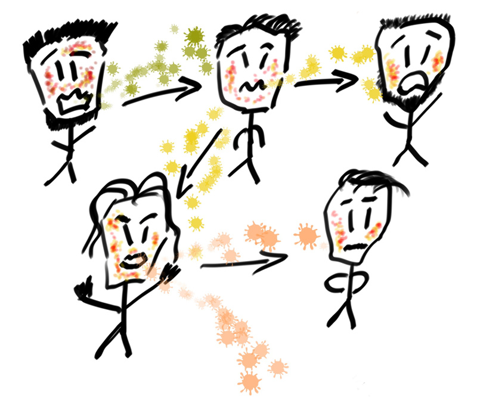

- transmission tree: directed acyclic graph representing transmission events of an outbreak
- transmission chain: path from a case to a descending case

## Why does it matter?

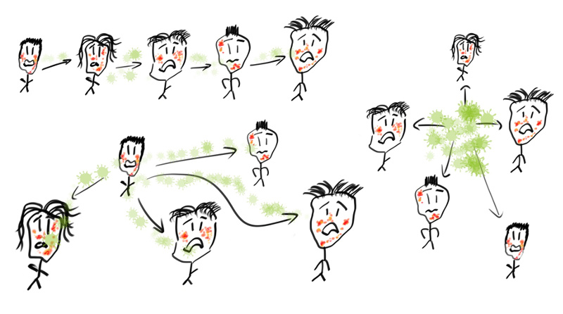

Different transmission contexts need different responses.

## A difficult problem

The number of possible transmission trees grows very fast:

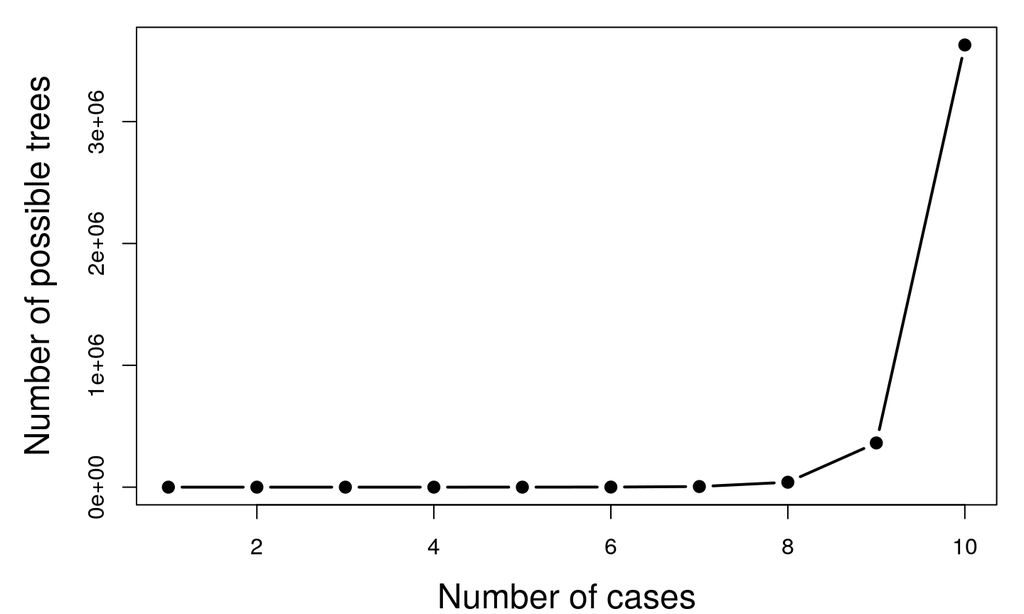

- for 10 cases with unique onsets, \(\sim 3,500,000\) trees
- for 60 cases with unique onsets, \(\sim 8^{81}\) trees (more or less the estimated number of atoms in the universe)

## Some data can be informative

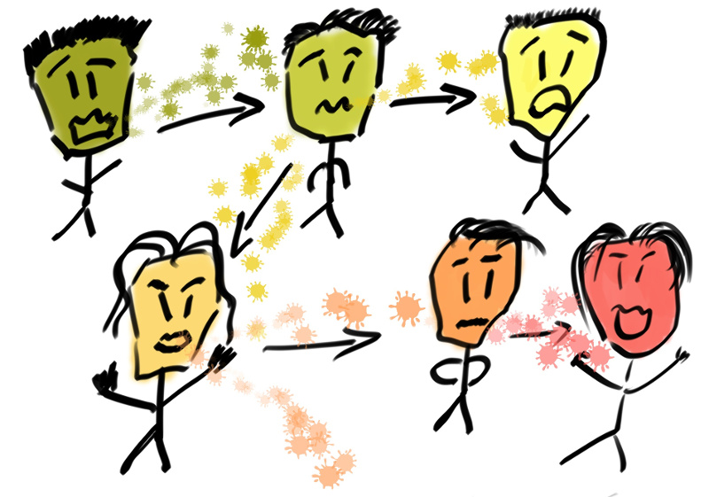

- mutations accumulate in the pathogen genome along the transmission chains
- can be used to reconstruct transmission trees

## But even genomic data have limits

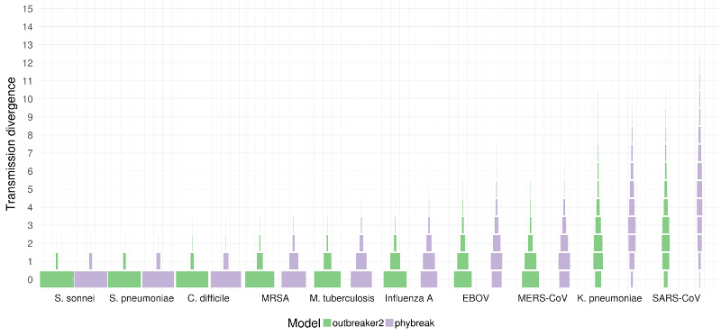

For most diseases, whole genome sequences alone are not sufficient for reconstructing transmission trees.

## An evidence synthesis approach

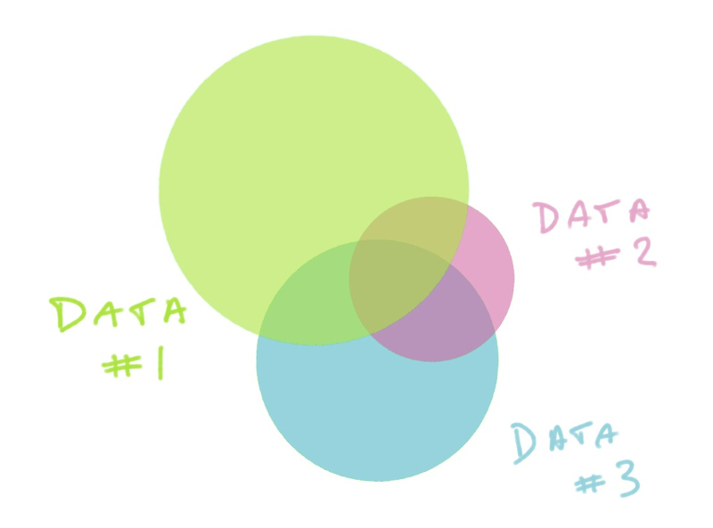

- data (e.g. dates of symptom onset) restrict possible trees
- combine different types of data to identify a small set of plausible trees

## Outbreak reconstruction using *outbreaker2*

## Original idea of *outbreaker*

Original *outbreaker* model used serial interval and genetic data to reconstruct transmission events.

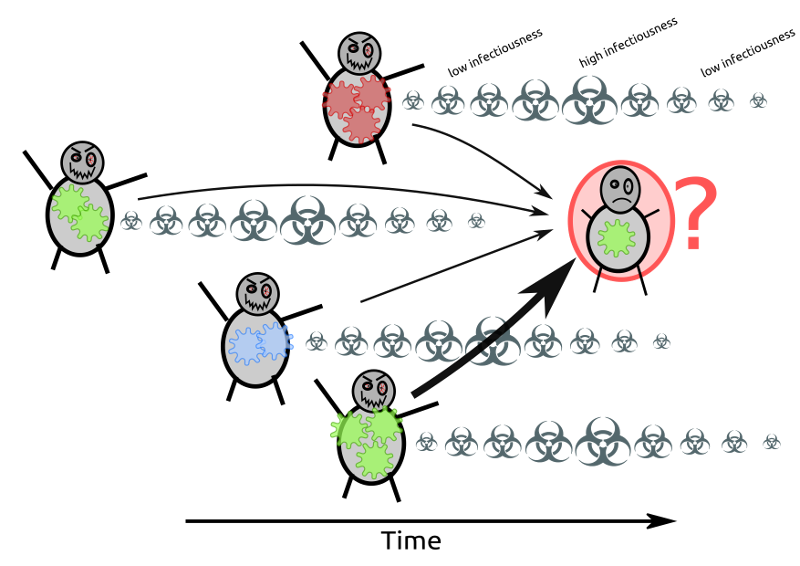

## *outbreaker2*: a modular platform for outbreak reconstruction

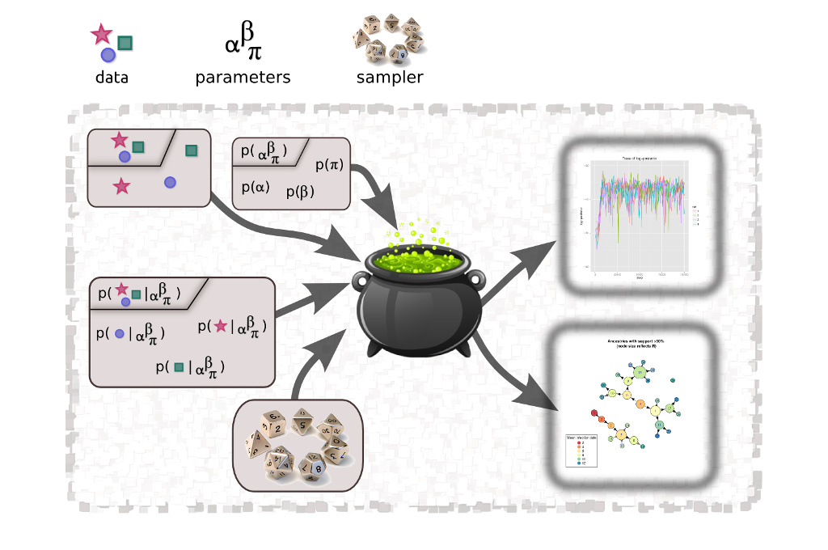

## Temporal likelihood

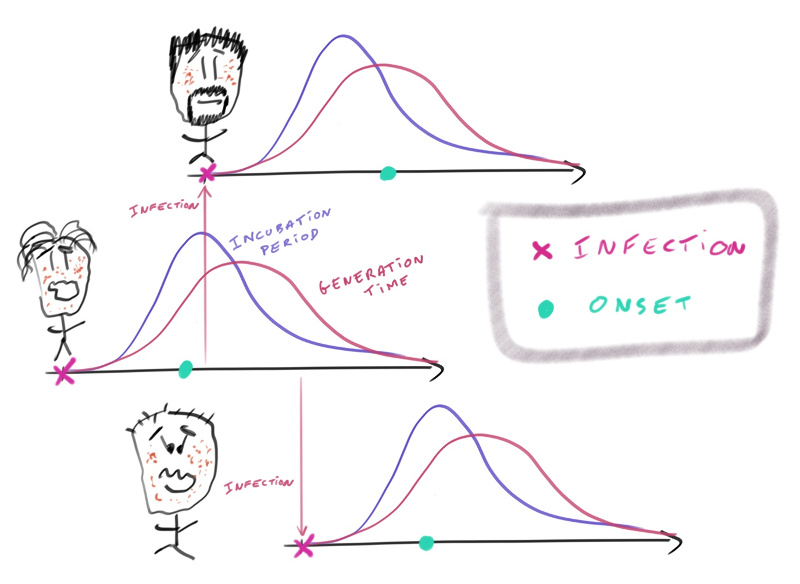

Combines generation time, incubation period, and dates of onset.

## Temporal likelihood

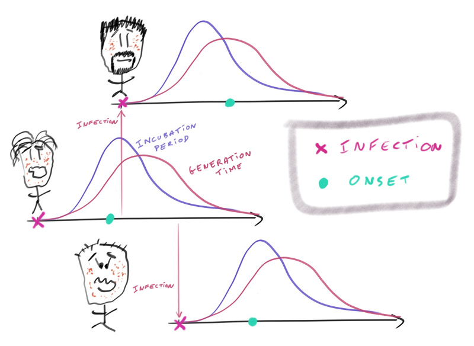

Dates of symptom onset (\(t_i\)), generation time (\(w()\)), incubation period (\(f()\)), number of generations (\(\kappa_i\)).

\[ p(t_i | T_i^{inf}) \times p(T_i^{inf} | T_{\alpha_i}^{inf}, \kappa_i) = f(t_i - T_i^{inf}) \times w^{(\kappa_i)}(T_i^{inf} - T_{\alpha_i}^{inf}) \]

## Reporting likelihood

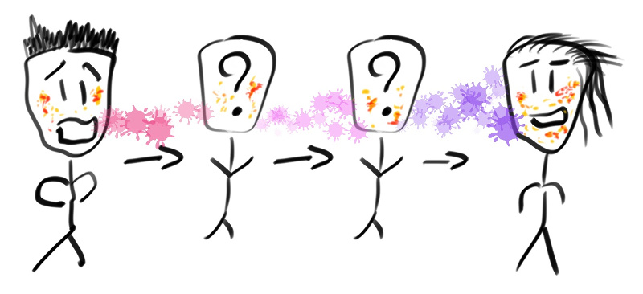

- \(\kappa_i\): number of generations between case \(i\) and its more recent sampled "ancestor"; \(\pi\) case reporting probability

**Geometric distribution:**

\[ p(\kappa_i | \pi) = (1 - \pi^{})^{\kappa_i - 1} \times \pi \]

## Genetic likelihood

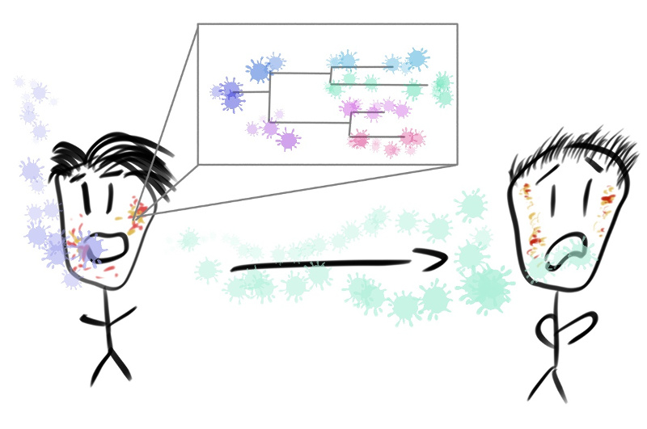

- \(d()\): number of mutations between 2 sequences; \(s_i\), \(s_{\alpha_i}\): sequences of infectee their infector; \(L\): genome length; \(\mu\): mutation rate per generation of infection

\[ p(s_i | s_{\alpha_i} \mu) = \mu^{d(s_i, s_{\alpha_i})} \times (1 - \mu)^{(\kappa_i L - d(s_i, s_{\alpha_i}))} \]

## Contact likelihood

**Relies on:** contact reporting probability (\(\epsilon\)) and probability of contact between non-transmission pairs (\(\lambda\)).

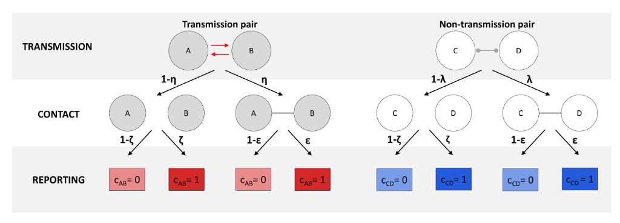

\(\alpha_i = j\): \(p(c_{i,j} = 1 ) = \epsilon\) ; \(p(c_{i,j} = 0) = 1 - \epsilon\)

\(\alpha_i \neq j\): \(p(c_{i,j} = 1) = \lambda \epsilon\) ; \(p(c_{i,j} = 0) = (1 - \lambda) + \lambda (1 - \epsilon)\)

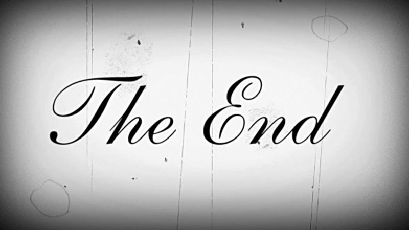